# Mushroom example answers

Steve Paterson

2024-10-02

There is no single right or wrong answer to this, the approach is flexible regarding what questions to ask. In the code and below I’ve outlined an approach and some potential figures. Note that for the report you should try to use the language and tone that you would use in a scientific paper. I won’t produce a model answer in it’s entirety, but I’ll indicate some ways of presenting methods and results.

## Some examples of analysis

First read in the data using `read.csv` or `read_csv`. We’ll also be using `ggplot` within tidyverse.

```r
library(tidyverse)
mushroom <- read_csv("mushroom_5k.csv")
```

For yourself, you need to get some feel for the data (you can also use `View`).

```r
summary(mushroom)
```

```
##     class            cap.diameter     stem.height        colour
##  Length:5000        Min.   : 0.380   Min.   : 0.000   Length:5000
##  Class :character   1st Qu.: 3.450   1st Qu.: 4.630   Class :character
##  Mode  :character   Median : 5.940   Median : 5.930   Mode  :character
##                     Mean   : 6.856   Mean   : 6.582
##                     3rd Qu.: 8.590   3rd Qu.: 7.670
##                     Max.   :62.340   Max.   :31.360
##  water.content
##  Min.   :30.01
##  1st Qu.:39.91
##  Median :50.10
##  Mean   :49.86
##  3rd Qu.:59.73
##  Max.   :69.98
```

Here class and colour need to be changed to a factor.

```r
mushroom$class <- as.factor(mushroom$class)
mushroom$colour <- as.factor(mushroom$colour)
summary(mushroom)
```

```
##        class       cap.diameter     stem.height       colour
##  edible   :2268   Min.   : 0.380   Min.   : 0.000   brown:2288
##  poisonous:2732   1st Qu.: 3.450   1st Qu.: 4.630   grey :1971
##                   Median : 5.940   Median : 5.930   red  : 741
##                   Mean   : 6.856   Mean   : 6.582
##                   3rd Qu.: 8.590   3rd Qu.: 7.670
##                   Max.   :62.340   Max.   :31.360
##  water.content
##  Min.   :30.01
##  1st Qu.:39.91
##  Median :50.10
##  Mean   :49.86
##  3rd Qu.:59.73
##  Max.   :69.98
```

If there is missing data, you may need to consider it removing it before further analysis.

I would start just by doing some plots to get a feel for the data.

Using this sort of format, you can plot up various parameters for edible versus poisonous mushrooms.

[figure not shown]

```r
sh.plot <- ggplot(data=mushroom,aes(x=class,y=stem.height))
sh.plot +  geom_boxplot() + theme_classic(base_size=16) + labs(x="",y="Stem height (mm)")
```

If you want to get mean, standard deviation and standard error, you can work out for each group, or the code below will do quickly

```r
mushroom %>% group_by(class) %>% summarise(mean_sh=mean(stem.height),sd_sh=sd(stem.height),se_sh=sd(stem.height)/sqrt(n()))
```

```
## # A tibble: 2 × 4
##   class     mean_sh sd_sh  se_sh
##   <fct>       <dbl> <dbl>  <dbl>
## 1 edible       7.07  3.76 0.0789
## 2 poisonous    6.18  3.07 0.0587
```

```r
mushroom %>% group_by(class) %>% summarise(mean_cd=mean(cap.diameter),sd_sh=sd(cap.diameter),se_sh=sd(cap.diameter)/sqrt(n()))
```

```
## # A tibble: 2 × 4
##   class     mean_cd sd_sh  se_sh
##   <fct>       <dbl> <dbl>  <dbl>
## 1 edible       8.07  7.02 0.147
## 2 poisonous    5.85  4.05 0.0774
```

```r
table(mushroom$class)
```

```
##
##    edible poisonous
##      2268      2732
```

To get a t test

```r
t.test(stem.height ~ class,data=mushroom)
```

```
##
##  Welch Two Sample t-test
##
## data:  stem.height by class
## t = 9.0994, df = 4361.7, p-value < 2.2e-16
## alternative hypothesis: true difference in means between group edible and group poisonous is not equal to 0
## 95 percent confidence interval:
##  0.701770 1.087216
## sample estimates:
##    mean in group edible mean in group poisonous
##                7.070895                6.176402
```

```r
t.test(cap.diameter ~ class,data=mushroom)
```

```
##
##  Welch Two Sample t-test
##
## data:  cap.diameter by class
## t = 13.334, df = 3472.4, p-value < 2.2e-16
## alternative hypothesis: true difference in means between group edible and group poisonous is not equal to 0
## 95 percent confidence interval:
##  1.893072 2.545786
## sample estimates:
##    mean in group edible mean in group poisonous
##                8.068880                5.849451
```

```r
t.test(water.content ~ class,data=mushroom)
```

```
##
##  Welch Two Sample t-test
##
## data:  water.content by class
## t = 0.044847, df = 4827.5, p-value = 0.9642
## alternative hypothesis: true difference in means between group edible and group poisonous is not equal to 0
## 95 percent confidence interval:
##  -0.6276752  0.6570647
## sample estimates:
##    mean in group edible mean in group poisonous
##                49.87165                49.85695
```

If you want to know whether colour is associated with being poisonous, you’ll need to use a Chi-square test.

```r
table(mushroom$class , mushroom$colour)
```

```
##
##             brown grey  red
##   edible     1065  895  308
##   poisonous  1223 1076  433
```

```r
chisq.test(mushroom$class , mushroom$colour)
```

```
##
##  Pearson's Chi-squared test
##
## data:  mushroom$class and mushroom$colour
## X-squared = 5.6078, df = 2, p-value = 0.06057
```

So this is not significant.

Some of you might also have produced a plot of cap diameter versus stem height.

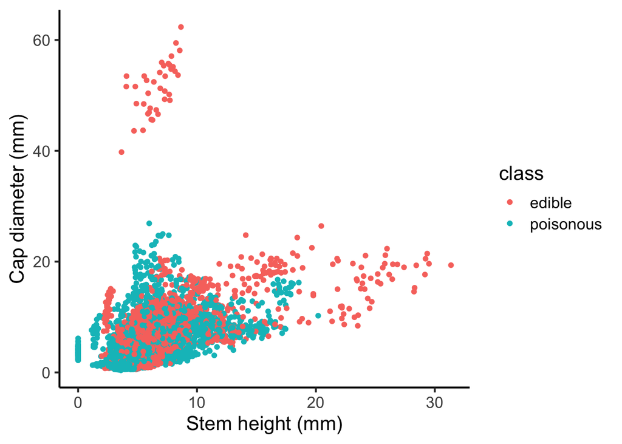

```r
m.plot1 <- ggplot(data=mushroom,aes(x=stem.height,y=cap.diameter,color=class))
m.plot1 + geom_point() + labs(x="Stem height (mm)",y="Cap diameter (mm)") +
  theme_classic(base_size=16)
```

This is quite interesting in that it highlights a group of edible mushrooms with a large cap diameter as a discrete group to the top of the plot. Also mushrooms with a large stem height tend not to be poisonous (to the right of the plot). Please don’t use this example to make choices on eating wild mushrooms though.

## Writing methods

You are asked to put all commands into an appendix, so don’t put R code in the methods. You will be marked down if you do this. here you can include a description of the data set that was available and the tests used.

‘A data set of 5000 records of mushrooms was analysed, consisting of 2268 edible and 2732 poisonous mushrooms. The stem height (in mm),cap diameter (in mm), water content (percentage) and colour (classified as brown, grey or red) was available for each record. Data are summarised in Table 1. Data were read in to R (version x.x) checked for missing data and outliers. Plots were produced with ggplot and t-tests/Chi-square tests used to compare <*insert whatever your hypotheses are*>.’

## Reporting results

Remember to put a numbered figure legend below each figure. e.g. ‘Figure 1. Stem height (in mm) for edible and poisonous mushrooms’

For a t-test, your job is to convert R output to readable text. Something like: ‘The average stem height for edible mushrooms was 7.07mm (± 3.76mm s.d., n = 2268) and for poisonous mushrooms was 6.18mm (± 3.07mm s.d., n= 2732), which was found to be significantly different using a Welch two sample t-test (t=9.099, d.f. = 4361.7, p < 0.001). This is shown in Figure 1.’.

You could also write ‘Edible mushrooms had a significantly larger stem height (7.07±3.76mm s.d., n = 2268) than poisonous mushrooms (6.18±3.07mm s.d., n= 2732; two sample Welch t-test, t=9.099, d.f. = 4361.7, p < 0.001).’

The important things are that the reader should know which group is bigger, what the sizes are, what test is used and the test statistic and p-value.

For a Chi-square test, something like, ‘Colour was not significantly associated with whether a mushroom was edible or poisonous (Chi-square = 5.61, d.f. = 2, n.s.)’. But if there were a difference, you’d have to explain which cell of the table had more individuals than expected (e.g. if you’d found that red mushrooms tended to be poisonous).

## Word limit

You have a much higher word limit than you need. Don’t assume that adding more text gets you more marks. Being able to write clearly means writing concisely. An excellent answer might only be 3- 4 paragraphs of text plus figures/tables.

## Appendix

Your code should go into an appendix, not the main document. Annotated code means adding comments with a ‘#’ that let the marker, a colleague or your future self, understand not just what commands you’ve used but why. The ‘#’ means that the commands in the script can be run with R ignoring the comments. An example is given below.

```r
#Analysis of mushroom data 2/10/24
#Does the colour of a mushroom predict whether it's poisonous?

#produce a table of class by colour
table(mushroom$class , mushroom$colour)

#perform a Chi-sq test
chisq.test(mushroom$class , mushroom$colour)
#this is not significant
```